# PRÁCTICA 4: PÉNDULO SIMPLE

**Autor responsable:** Víctor Mula Navarro

**Autores**: Pablo Corbalán de Concepción y Víctor Mula Navarro.

**Grupo:** G4 - DTIE.

**Fecha del informe:** 05/03/2026.

## INFORMACIÓN GENERAL DEL LABORATORIO

**Fecha de realización de la práctica:** 26/02/2026.

**Temperatura:** 22.5ºC

**Humedad relativa:** 41%

**Presión:** 1036.8 hPa

## 1. INTRODUCCIÓN Y OBJETIVOS

El péndulo simple ideal consiste en un hilo inextensible de longitud $l$ y masa despreciable, en cuyo extremo cuelga una masa $m$ de tamaño también despreciable. El otro extremo se sujeta a un punto fijo de modo que, al desplazarlo un ángulo $\theta_{0}$ de su posición vertical y soltarlo, comienza a oscilar. En un laboratorio, con las herramientas adecuadas, podemos simular este movimiento y estudiar sus características.

En particular, es intersante reparar en el efecto que tiene el ángulo de apertura $ \theta_{0}$ en las oscilaciones y la rapidez con la que el péndulo se mueve alrededor de su punto de equilibrio. En la teoría, la mayoría de veces se trabaja con ecuaciones que corresponden a aproximaciones de primer orden, por tanto, modelizan los problemas de forma aproximada, distando del comportamiento real del cuerpo.

Como consecuencia de lo anterior, será notoria la diferencia que existirá cuando se trabaje con ángulos de apertura pequeños y otros más grandes, puesto que deberemos ajustar las fórmulas correspondientes para obtener resultados fidedignos a la experiencia física. A colación de este resultado, cabe resaltar que en las expresiones matemáticas utilizadas no se tiene en cuenta el rozamiento debido al aire y la consiguiente pérdida de energía mecánica que trae consigo. Idealmente, el péndulo mantiene una amplitud de oscilación constante, que no se ve afectada por el paso del tiempo. Sin embargo, en la práctica, sí se ve amortiguado y, por tanto, la amplitud se va reduciendo a cada oscilación. Este fenómeno se hace denotar a mayor es el ángulo $\theta_{0}$.

Los principales objetivos de esta práctica son los siguientes:

- Comprobar la ley del péndulo simple tanto para pequeñas como para grandes oscilaciones.
- Determinar la aceleración de la gravedad ($g$) mediante el análisis del periodo frente a la longitud.
- Investigar la validez de la aproximación de pequeñas oscilaciones (ecuación particular) frente a la ecuación general.
- Analizar el efecto de la amplitud representando $T/T_{0}$ frente a $\sin^2(\theta_{0}/2)$.
- Identificar causas de error experimentales como la masa del hilo, oscilaciones no planas o el momento de inercia de la masa.

## 2. Marco teórico general

Como se ha mencionado en el apartado anterior, el movimiento oscilatorio efectuado por el péndulo se rige por el Principio de Conservación de la energía:

$$mgl(1-\cos \theta) + \frac{1}{2}m\left(l\frac{d\theta}{dt}\right)^2 = E_0 \tag{1}$$

Donde el primer término hace referencia a la energía potencial, el segundo término a la energía cinética del péndulo y $E_0$ es la energía total, que viene dada por la expresión $E_0 = mgl(1 - \cos \theta_0)$. Resolviendo la ecuación diferencial obtenemos la expresión aproximada para el periodo de oscilación en función de la amplitud inicial:

$$T \approx 2\pi\sqrt{\frac{l}{g}} \left( 1 + \frac{1}{4}\sin^2\frac{\theta_0}{2} + \frac{9}{64}\sin^4\frac{\theta_0}{2} + \dots \right)~\tag{2}$$

Para pequeñas amplitudes, las correcciones debidas a $\theta_{0}$ se pueden despreciar, resultando en un periodo $T$ que depende únicamente de la longitud y la gravedad:

$$T = T_{0} = 2\pi\sqrt{\frac{l}{g}} \tag{3}$$

Lo cual nos permite relacionar de manera lineal las magnitudes $T^2$ y $l$ y, por tanto, hacer un ajuste por mínimos cuadrados, en el que la pendiente nos proporcionará de manera experimental el valor de la gravedad $g$ con su correspondiente incertidumbre $u_g$:

$$ T^2 = \frac{4 \pi^2}{g} l \tag{4}$$

Para la segunda parte del experimento, nos quedaremos con el segundo término en la aproximación de T:

$$ T = T_0\cdot(1 + \frac{1}{4} \sin^2 \frac{\theta_0}{2})$$ $$ \frac{T}{T_0} = 1 + \frac{1}{4} \sin^2 \frac{\theta_0}{2} \tag{5}$$

Ecuación que nos permitirá hacer un ajuste por mínimos cuadrados de $\frac{T}{T_0}$ frente a $\sin^2 \frac{\theta_0}{2}$. La pendiente tendrá que ser aproximadamente $\frac{1}{4}$ y la ordenada en el origen, $1$. De esta forma, comprobaremos que esta aproximación es válida cuando se trabaja con valores de $\theta_0$ que se alejan de ser nulos.

Hemos de tener en cuenta también diferentes factores que afectan a que los resultados no sean los esperados según la teoría. Estamos haciendo suposiciones a la hora de construir estas fórmulas que no tienen por qué cumplirse en la realización del experimento. Hemos de considerar que la masa no es ideal y su momento de inercia no es el de una masa puntual, que el hilo tiene masa y está sujeto a tensiones variables que acompañan a la osiclación y que el péndulo no siempre oscila exactamente en un plano 2 dimensional. Todos estos factores contribuyen a aumentar el error en las mediciones realizadas.

### 2.1 Determinación de la amplitud para que el error sea inferior al 1%

Para determinar el ángulo máximo $\theta_0$ en el cual la aproximación de pequeñas oscilaciones sigue siendo válida con un error inferior al 1%, comparamos la ecuación del periodo ideal $T_0$ con la aproximación de primer orden de la ecuación general:

$$T \approx T_0 \left( 1 + \frac{1}{4} \sin^2 \frac{\theta_0}{2} \right)$$

Definimos el error relativo como:$$\epsilon = \frac{T - T_0}{T} < 0,01$$

Sustituyendo la expresión de $T$:

$$\frac{T_0 \left( 1 + \frac{1}{4} \sin^2 \frac{\theta_0}{2} \right) - T_0}{T_0 \left( 1 + \frac{1}{4} \sin^2 \frac{\theta_0}{2} \right)} = 0,01$$

Simplificando $T_0$ y restando los términos del numerador:

$$\frac{\frac{1}{4} \sin^2 \frac{\theta_0}{2}}{1 + \frac{1}{4} \sin^2 \frac{\theta_0}{2}} = 0,01$$

Para resolverlo, despejamos el término del seno:

$$\frac{1}{4} \sin^2 \frac{\theta_0}{2} = 0,01 \left( 1 + \frac{1}{4} \sin^2 \frac{\theta_0}{2} \right)$$$$\frac{1}{4} \sin^2 \frac{\theta_0}{2} (1 - 0,01) = 0,01$$$$\sin^2 \frac{\theta_0}{2} = \frac{0,04}{0,99} \approx 0,0404$$$$\sin \frac{\theta_0}{2} = \sqrt{0,0404} \approx 0,201$$$$\frac{\theta_0}{2} = \arcsin(0,201) \approx 11,59^\circ$$$$\theta_0 \approx 23,18^\circ$$

## 3. Montaje experimental y procedimiento seguido

### 3.2 Experiencia 1: Determinación de la aceleración debida a la gravedad

En esta fase trabajamos con amplitudes iniciales pequeñas $\theta_0 \approx 0$ para así poder emplear la aproximación lineal del periodo. El procedimiento seguido en esta experiencia es:

1. Determinar la distancia $H$ desde el techo hasta el suelo. Para cada medición, registramos la altura $h$ desde el centro de la bola al suelo, obteniendo la longitud efectiva del péndulo como: $$l = H - h \tag{6}$$
2. Se separa el péndulo de la vertical con un ángulo pequeño y se libera, evitando movimientos laterales. Medimos tres veces el tiempo que el péndulo tarda en oscilar veinte veces. Este proceso se repite para cada una de las cinco longitudes del péndulo
3. El periodo experimental se obtiene mediante $T = \overline{t_n} / n$, siendo $\overline{t_n} $ el valor medio de las $3$ mediciones tomadas.

### 3.3 Experiencia 2: Comportamiento del péndulo para amplitudes mayores

La segunda experiencia busca comparar el comportamiento real del péndulo frente al modelo ideal cuando el ángulo inicial $\theta_0 \not \approx 0$.

1. En primer lugar, fijamos una longitud $l$ del péndulo constante: situando la esfera a la altura del borde de la mesa donde se coloca una cinta métrica. Así utilizaremos el desplazamiento lateral $\Delta x$ para determinar el ángulo inicial mediante la relación $$\tan \theta_0 = \frac{\Delta x} {l} \tag{7}$$
2. Registramos los tiempos para 20 oscilaciones del péndulo para cinco medidas del valor de $\Delta x$.

## 4. Resultados

### 4.1 EXPERIENCIA 1

#### 4.1.1 Experiencia 1: Medidas directas de altura y tiempo

| $i$ | $h$ (cm) | $n$ | $t_n^{(1)}$ (s) | $t_n^{(2)}$ (s) | $t_n^{(3)}$ (s) |
| --- | --- | --- | --- | --- | --- |
| 1 | 129.5 | 20 | 51.62 | 50.81 | 51.25 |
| 2 | 110.0 | 20 | 52.58 | 53.73 | 54.08 |
| 3 | 142.0 | 20 | 49.24 | 48.40 | 49.44 |
| 4 | 161.5 | 20 | 45.72 | 46.00 | 45.70 |
| 5 | 62.8 | 20 | 60.46 | 60.63 | 60.67 |

La altura $h^{(i)}$ no lleva asociada incertidumbre de tipo A, pues solo se ha tomado una medida para cada $1 \leq i \leq 5$. La incertidumbre tipo B asociada a la altura viene dada por la resolución de la cinta métrica $\Delta = 0.01cm$. Por ser un instrumento analógico asumiremos que su función de probabilidad sigue una distribución triangular.

$$u_B(h^{(i)})^2 = \frac{\Delta^2} {24} \implies u_{h^{(i)}} = u_B(h^{(i)}) = \frac{\Delta}{\sqrt{24}} = 0.0020$$

Cada una de las medidas del tiempo $t_n^{(j)}$ (para $j = 1, 2, 3$) llevará asociada incertidumbre tipo B. Por ser el cronómetro (de resolución $\Delta = 0.01s$) digital asumimos que sigue una distribución rectangular de probilidad. Así:

$$u_B(t_n^{(j)})^2 = \frac{\Delta^2} {12} \implies u_B(t_n^{(j)}) = \frac{\Delta}{\sqrt{12}} = 0.0029$$

Donde no estamos considerando la incertidumbre debida al tiempo de reacción humano.

Para la incertidumbre tipo A asociada a las mediciones de los tiempos, debemos calcular primero la el valor medio asociada a cada altura:

$$ \overline t_i = \frac{\sum_{j = 1}^{3} t_{n_{i}}^{(j)}}{3} $$

Así, su incertidumbre tipo A vendrá dada por la expresión:

$$ u_{a_{i}} = \frac{s_i}{\sqrt{3}} $$

Finalmente, la incertidumbre total será:

$$ u_{t_{i}}^2 = u_{a_{i}}^2 + u_b^2$$

Para la longitud del péndulo ($l = H - h$), debemos considerar que tanto la altura del techo ($H$) como la altura de la bola al suelo ($h$) poseen la misma incertidumbre instrumental de la cinta métrica, $u_B = 0.0020 \text{ cm}$.

En cuanto al periodo $T = \frac{\overline{t_n}}{n}$, la incertidumbre asociada a una única oscilación se reduce por el factor $n$: $$u_{T_i} = \frac{u_{t_i}}{n}$$

$$u_{T_i^2} = 2 \overline{T_i} \cdot u_{T_i}$$

#### 4.1.2 Ajuste lineal $T^2$ frente a $l$

Para cada medida de $h$ en la sección 4.1.1 se hace el cálculo de $l$ usando la ecuación$(6)$. Se tendrá también en cuenta la incertidumbre asociada a $T^2$ en el ajuste. La tabla de datos queda pues de la siguiente forma:

| $T^2$ ($s^2$) | $u_{T^2}$ ($s^2$) | $l$ (m) |
| --- | --- | --- |
| 6.560 | 0.059 | 1.635 |
| 7.15 | 0.12 | 1.830 |
| 6.009 | 0.078 | 1.510 |
| 5.246 | 0.022 | 1.315 |
| 9.177 | 0.020 | 2.302 |

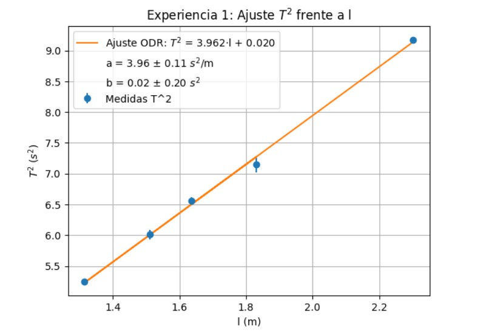

Sabemos, por tanto que:

Con su respectiva incertidumbre:

$$ u_g = g \cdot \frac{u_a}{a} = 9.97 \cdot \frac{0.11}{3.96} = 0.28 \frac{m}{s^2}$$

En conclusión:

### 4.2 EXPERIENCIA 2

#### 4.2.1 medidas directas tomadas para la experiencia 2

[output not shown]

#### Cálculo del periodo con su incertidumbre asociada

El periodo se define como el tiempo medio entre el número de oscilaciones $n$. La incertidumbre del periodo $T$ se propaga como:

$$u_T = \frac{u_{\bar{t}_n}}{n}$$

El ángulo inicial $\theta_0$ se determina mediante la relación trigonométrica con el desplazamiento horizontal $\Delta x$ y la altura efectiva $H-h$

$$\theta_0 = \arctan\left(\frac{\Delta x}{H-h}\right)$$

#### Cálculo del ángulo asociado a $\Delta x$

La incertidumbre del ángulo en radianes se calcula mediante la fórmula de propagación de incertidumbres aplicada a la anterior expresión:

$$u_{\theta_{rad}} = \frac{1}{\Delta x^2 + (H-h)^2} \sqrt{\Delta x^2 (u_H^2 + u_h^2) + (H-h)^2 u_{\Delta x}^2}$$

Donde $u_H$, $u_h$ y $u_{\Delta x}$ son las incertidumbres típicas combinadas asociadas a la altura entre el suelo y el techo, la altura entre el suelo y la masa del péndulo y la separación respecto la vertical del péndulo previo a ser soltado respectivamente. Para el ajuste lineal, se utiliza la variable $\sin^2(\theta_0/2)$. Su incertidumbre asociada se obtiene, por la fórmula de propagación de incertidumbres, derivando la función respecto a $\theta$:

$$u_{\sin^2(\frac{\theta_0}{2})} = \frac{1}{2} |\sin(\theta_0)| u_{\theta_{rad}}$$

#### Cálculo de la pendiente de la regresión lineal

$$u_m = \sqrt{P_{C[0,0]}}$$

Así, tras realizar la regresión de los siguientes valores:

| i | $\sin^2(\theta_0/2)$ | $T/T_0$ |
| --- | --- | --- |
| 1 | $0.004464 \pm 0.000001$ | $0.9946 \pm 0.0064$ |
| 2 | $0.014547 \pm 0.000001$ | $1.0041 \pm 0.0091$ |
| 3 | $0.029368 \pm 0.000002$ | $1.0044 \pm 0.0074$ |
| 4 | $0.043772 \pm 0.000002$ | $1.0049 \pm 0.0054$ |
| 5 | $0.022951 \pm 0.000001$ | $1.0075 \pm 0.0052$ |

Se ha obtenido la siguiente gráfica:

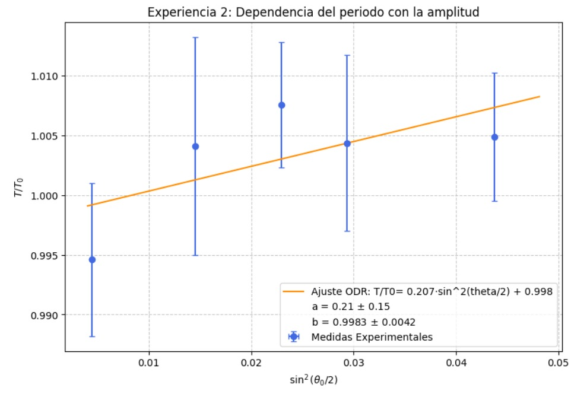

## 5. CONCLUSIONES

### 5.1 DETERMINACIÓN VALOR GRAVEDAD

En la experiencia, hemos obtenido un valor de la gravedad de

Si lo comparamos con el valor bibliográfico $g_{bibliografia} = 9.80 \frac{m}{s^2}$, obtenemos que se ha cometido un error relativo de

$$ \epsilon_r = \frac{9.80 - 9.97}{9.80} = -0.017 = -1.7%$$

Lo cual arroja que las medidas tomadas así como las aproximaciones consideradas en las fórmulas matemáticas empleadas aportan valores que se corresponden altamente con la bibliografía. Por tanto, para ángulos pequeños, las aproximaciones de primer orden de la fórmula $(2)$ son válidas ya que no se alejan en gran medida del valor bibliográfico.

### 5.2 COMPROBACIÓN DE LA INFLUENCIA DE LA AMPLITUD INICIAL EN EL PERIODO

En esta sección se investigó la validez de la aproximación de pequeñas amplitudes frente al modelo general del péndulo simple. A partir del análisis de la relación entre el periodo relativo $T/T_0$ y el término de amplitud $\sin^2(\theta_0/2)$, se obtuvieron los siguientes resultados mediante un ajuste lineal:

## 6. Bibliografía

Instituto Geográfico Nacional. (n.d.). Buscador de estaciones gravimétricas: Murcia. Ministerio de Transportes, Movilidad y Agenda Urbana. https://www.ign.es/web/ign/portal/grv-consultas-2007/-/gravedad-absoluta/BusquedaGravimetrica?area=Por%20nombre&busquedaPorNombre=empieza&textoBusquedaPorNombre=Murcia

Departamento de Física. (s.f.). Práctica 4: Péndulo simple [Guía de laboratorio]. Universidad de Murcia.

## 7. Anexos: Cálculos de Python

Para realizar los cálculos cargamos las siguientes librerías

```python
import numpy as np
import matplotlib.pyplot as plt
from scipy.odr import *
from matplotlib.lines import Line2D
```

### 7.1 Calculos de la experiencia 1

#### 7.1.1 Medidas directas

```python
def incertidumbreB_distribucion_triangular(resolucion):
    return resolucion / (24 ** 0.5)

def incertidumbreB_distribucion_rectangular(resolucion):
    return resolucion / (12 ** 0.5)

def incertidumbre_tipica_combinada(uA, uB):
    return (uA**2 + uB**2)**0.5

def incertidumbreA(s, N):
    return s / (N ** 0.5)
resolucion_cinta_metrica = 0.01 # cm
resolucion_cronometro    = 0.01 # s
```

```python
uBhi = incertidumbreB_distribucion_triangular(resolucion_cinta_metrica)
uBtj = incertidumbreB_distribucion_rectangular(resolucion_cronometro)
print(f"Incertidumbre B (h^i) : u_B(h^i) = {uBhi:.4f} cm")
print(f"Incertidumbre B (t^j) : u_B(t^j) = {round(uBtj, 4)} s")
```

```
Incertidumbre B (h^i) : u_B(h^i) = 0.0020 cm
Incertidumbre B (t^j) : u_B(t^j) = 0.0029 s
```

```python
indices = np.array([1, 2, 3, 4, 5])
alturas_pendulo  = np.array([129.5, 110.0, 142.0, 161.5, 62.8])
numero_oscilaciones = np.array([20, 20, 20, 20, 20])
# t1, t2, t3: Medidas de tiempo en segundos para cada i
t1 = np.array([51.62, 52.58, 49.24, 45.72, 60.46])
t2 = np.array([50.81, 53.73, 48.40, 46.00, 60.63])
t3 = np.array([51.25, 54.08, 49.44, 45.70, 60.67])
```

```python
def formatear(lista, titulo="", unidad="s", csig = []):
    print(titulo)
    for i in range(len(lista)):
        if csig == []:
            print(f"{i+1} : {lista[i]} {unidad}")
        else:
            n = round(lista[i], csig[i])
            l = (csig[i]-len(str(n).split(".")[1])) # numero de cifras significativas - numero de cifras decimales
            magnitud = str(n) + "0" * l
            print(f"{i+1} : {magnitud} {unidad}")
```

#### 7.1.2 Tiempo medio

Calculamos los tiempos medios para cada medida realizada:

```python
t_medios = []
for i in range(len(indices)):
    tiempo_medio = (t1[i]+t2[i]+t3[i]) / 3
    t_medios.append(tiempo_medio)
formatear(t_medios, titulo="Tiempos medios <t_n>", csig=[2,2,2,3,3])
```

```
Tiempos medios <t_n>
1 : 51.23 s
2 : 53.46 s
3 : 49.03 s
4 : 45.807 s
5 : 60.587 s
```

Calculamos las incertidumbres asociadas a los tiempos medios (tipo A, tipo B y combinada):

```python
# Incertidumbre tipo B
uB_t_medios = [uBhi, uBhi, uBhi, uBhi, uBhi]
# Incertidumbre tipo A
uA_t_medios = []
for i in range(len(indices)):
    s = np.std( [t1[i], t2[i], t3[i]] , ddof=1)
    uA_tiempo_medio = incertidumbreA(s, 3)
    uA_t_medios.append(uA_tiempo_medio)
# Incertidumbre típica combinada
u_tiempos_medios = []
for i in range(len(indices)):
    uA = uA_t_medios[i]
    uB = uB_t_medios[i]
    u_tiempo_medio = incertidumbre_tipica_combinada(uA, uB)
    u_tiempos_medios.append(u_tiempo_medio)
formatear(u_tiempos_medios, titulo="Incertidumbre tiempos medios u_<t_n>", csig=[2,2,2,3,3])
```

```
Incertidumbre tiempos medios u_<t_n>
1 : 0.23 s
2 : 0.45 s
3 : 0.32 s
4 : 0.097 s
5 : 0.064 s
```

#### 7.1.3 Longitud

Calculamos las longitudes del péndulo para las cinco medidas tomadas:

```python
H = 293 # cm
longitudes_pendulo = [(H - h)/100 for h in alturas_pendulo] #Conversión a metros
formatear(longitudes_pendulo, titulo="Longitudes l", unidad="cm", csig=[4,4,4,4,4])
```

```
Longitudes l
1 : 1.6350 cm
2 : 1.8300 cm
3 : 1.5100 cm
4 : 1.3150 cm
5 : 2.3020 cm
```

La incertidumbre de estas medidas será de tipo B, pues solo se ha tomado una medida de la altura para cada $1\leq i \leq 5$. Así:

```python
u_longitudes = []
for i in range(len(indices)):
    u_longitudes.append(uBhi)
formatear(u_longitudes, titulo="Incertidumbre longitudes u_l", unidad="cm", csig=[4,4,4,4,4])
```

```
Incertidumbre longitudes u_l
1 : 0.0020 cm
2 : 0.0020 cm
3 : 0.0020 cm
4 : 0.0020 cm
5 : 0.0020 cm
```

#### 7.1.4 Periodo

Calculamos el valor medio del periodo (con su respectiva incertidumbre asociada):

```python
T_medios = [t_medios[i] / numero_oscilaciones[i] for i in range(len(indices))]
formatear(T_medios, titulo="Periodo T", csig=[3,3,3,4,4])
```

```
Periodo T
1 : 2.561 s
2 : 2.673 s
3 : 2.451 s
4 : 2.2903 s
5 : 3.0293 s
```

```python
u_periodos_medios = []
for i in range(len(indices)):
    u_periodos_medios.append(u_tiempos_medios[i] / numero_oscilaciones[i])
formatear(u_periodos_medios, titulo="Incertidumbre periodo medio u_T", csig=[3,3,3,4,4])
```

```
Incertidumbre periodo medio u_T
1 : 0.012 s
2 : 0.023 s
3 : 0.016 s
4 : 0.0048 s
5 : 0.0032 s
```

Ya en condiciones de calcular el periodo al cuadrado con su respectiva incertidumbre:

```python
T2_medios = [T**2 for T in T_medios]
formatear(T2_medios, titulo="Periodo cuadrado T^2", unidad = "s^2", csig=[3,2,3,3,3])
```

```
Periodo cuadrado T^2
1 : 6.560 s^2
2 : 7.15 s^2
3 : 6.009 s^2
4 : 5.246 s^2
5 : 9.177 s^2
```

```python
u_periodos2_medios = []
for i in range(len(indices)):
    # Propagación de incertidumbres para T^2 = f(T) -> u(T^2) = g(T^2)
    u_periodo2_medio = T2_medios[i] *(2* (u_periodos_medios[i] / T_medios[i]) )
    u_periodos2_medios.append(u_periodo2_medio)
formatear(u_periodos2_medios, titulo="Incertidumbre periodo cuadrado medio u_T^2", unidad = "s^2", csig=[3,2,3,3,3])
```

```
Incertidumbre periodo cuadrado medio u_T^2
1 : 0.060 s^2
2 : 0.12 s^2
3 : 0.078 s^2
4 : 0.022 s^2
5 : 0.020 s^2
```

#### 7.2 Ajuste lineal $T^2$ frente a $l$

```python
def Lineal (parameters, x):
    A, B = parameters
    y = np.multiply(A, x) + B
    return y
lin_model = Model(Lineal)
data = RealData(longitudes_pendulo, T2_medios, sy = u_periodos2_medios)
odr = ODR(data, lin_model, beta0 = [0., 1.])
out = odr.run()
out.pprint()
```

```
Beta: [0. 1.]
Beta Std Error: [0. 0.]
Beta Covariance: [[0. 0.]
 [0. 0.]]
Residual Variance: 0.0
Inverse Condition #: 0.0
Reason(s) for Halting:
  Problem is not full rank at solution
  Sum of squares convergence
```

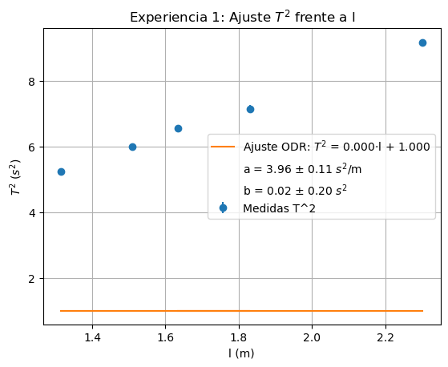

```python
fit_y = Lineal (out.beta, longitudes_pendulo)
plt.errorbar(longitudes_pendulo, T2_medios, yerr = u_periodos2_medios, linestyle = "None", marker = "o", label = "Medidas T^2")
plt.plot(longitudes_pendulo, fit_y, label = rf'Ajuste ODR: $T^2$ = {out.beta[0]:.3f}·l + {out.beta[1]:.3f}')
plt.plot ([], [], ' ', label = r"a = 3.96 $\pm$ 0.11 $s^2$/m")
plt.plot ([], [], ' ',label = r"b = 0.02 $\pm$ 0.20 $s^2$")
plt.title (r"Experiencia 1: Ajuste $T^2$ frente a l")
plt.xlabel ("l (m)")
plt.ylabel (r"$T^2$ ($s^2$)")
plt.grid()
plt.legend()
plt.show()
```

### 7.2 Cálculos de la experiencia 2

#### 7.2.1 Medidas directas

```python
import numpy as np

# i Medida (Índice de la medición)
indices_exp2 = np.array([1, 2, 3, 4, 5])

# Delta x (cm)
delta_x = np.array([30.00, 55.00, 80.00, 100.00, 70.00])

# n (Número de oscilaciones/eventos)
numero_oscilaciones_exp2 = np.array([20, 20, 20, 20, 20])

# Tiempos registrados t_20 (Segundos)
# Como las filas tienen distinta cantidad de datos, usamos una lista de listas
tiempos_tomados = [
    [59.51, 59.67],          # Medida 1
    [60.46, 60.02, 60.00],   # Medida 2
    [60.35, 60.00],          # Medida 3
    [60.23, 60.18],                 # Medida 4
    [60.40, 60.33]                  # Medida 5
]
```

#### 7.2.2 Tiempo medio

```python
tiempos_medios_exp2 = np.array([np.mean(t) for t in tiempos_tomados])

formatear(tiempos_medios_exp2, titulo="Tiempo medio", csig=[2,2,2,3,3])
```

```
Tiempo medio
1 : 59.59 s
2 : 60.16 s
3 : 60.18 s
4 : 60.205 s
5 : 60.365 s
```

```python
# Incertidumbre tipo B
uB_t_medios_exp2 = [uBhi, uBhi, uBhi, uBhi, uBhi]
# Incertidumbre tipo A
uA_t_medios_exp2 = []
for i in range(len(indices_exp2)):
    s = np.std( tiempos_tomados[i] , ddof=1)
    uA_tiempo_medio = incertidumbreA(s, 3)
    uA_t_medios_exp2.append(uA_tiempo_medio)

# Incertidumbre típica combinada
u_tiempos_medios_exp2 = []
for i in range(len(indices_exp2)):
    uA = uA_t_medios[i]
    uB = uB_t_medios[i]
    u_tiempo_medio = incertidumbre_tipica_combinada(uA, uB)
    u_tiempos_medios_exp2.append(u_tiempo_medio)
formatear(u_tiempos_medios_exp2, titulo="Incertidumbre tiempos medios u_<t_n>", csig=[2,2,2,3,3])
```

```
Incertidumbre tiempos medios u_<t_n>
1 : 0.23 s
2 : 0.45 s
3 : 0.32 s
4 : 0.097 s
5 : 0.064 s
```

### 7.2.3 Periodo

```python
T_medios_exp2 = [tiempos_medios_exp2[i] / numero_oscilaciones[i] for i in range(len(indices_exp2))]
formatear(T_medios_exp2, titulo="Periodo T", csig=[3,3,3,4,4])
```

```
Periodo T
1 : 2.980 s
2 : 3.008 s
3 : 3.009 s
4 : 3.0102 s
5 : 3.0182 s
```

```python
u_periodos_medios_exp2 = []
for i in range(len(indices_exp2)):
    u_periodos_medios_exp2.append(u_tiempos_medios_exp2[i] / numero_oscilaciones_exp2[i])
formatear(u_periodos_medios, titulo="Incertidumbre periodo medio u_T",  csig=[3,3,3,4,4])
```

```
Incertidumbre periodo medio u_T
1 : 0.012 s
2 : 0.023 s
3 : 0.016 s
4 : 0.0048 s
5 : 0.0032 s
```

#### 7.2.4 Cálculo de $\theta_0$

```python
h = 70
theta0_exp2 = [np.degrees(np.arctan( (dx)/(H - h) )) for dx in delta_x]
formatear(theta0_exp2, "Theta_0", " grados", csig=[5,5,5,5,5])
```

```
Theta_0
1 : 7.66195  grados
2 : 13.85474  grados
3 : 19.73516  grados
4 : 24.15292  grados
5 : 17.42714  grados
```

```python
# Incertidumbre asociada a a cada theta0:
dy = H - h
uH = uBhi
uh = uBhi
udx = uBhi

u_theta0_exp2 = []
for dx in delta_x:
    denominador = dx**2 + dy**2

    termino_numerador = np.sqrt( (dx**2 * (uH**2 + uh**2)) + (dy**2 * udx**2) )
    u_theta_rad = (1 / denominador) * termino_numerador

    # 4. Conversión a grados
    theta_deg = np.degrees(theta0_exp2)
    u_theta_deg = np.degrees(u_theta_rad)
    u_theta0_exp2.append(u_theta_deg)

formatear(u_theta0_exp2, "Incertidumbre de los ángulos u_{theta_0}", "grados", csig=[5,5,5,5,5])
```

```
Incertidumbre de los ángulos u_{theta_0}
1 : 0.00052 grados
2 : 0.00052 grados
3 : 0.00052 grados
4 : 0.00052 grados
5 : 0.00052 grados
```

#### 7.2.5 Cálculo de $\sin ^ 2 (\frac{\theta_0 }{2})$

```python
sin2_exp2 = [np.sin(np.deg2rad(theta0 / 2))**2 for theta0 in theta0_exp2]
formatear(sin2_exp2, titulo="Seno cuadrado de theta_0 medios", unidad="", csig=[8,7,7,7,7])
```

```
Seno cuadrado de theta_0 medios
1 : 0.00446402
2 : 0.0145470
3 : 0.0293683
4 : 0.0437717
5 : 0.0229507
```

```python
u_sin2_exp2 = []

for i in range(len(theta0_exp2)):
    th_rad = np.deg2rad(theta0_exp2[i]) # Ángulo en radianes
    u_th_rad = np.deg2rad(u_theta0_exp2[i]) # Incertidumbre en radianes

    # Propagación
    incertidumbre = 0.5 * np.abs(np.sin(th_rad)) * u_th_rad

    u_sin2_exp2.append(incertidumbre)

formatear(u_sin2_exp2, titulo="Incertidumbre de sin^2(theta_0/2)", unidad="", csig=[8,7,7,7,7])
```

[output not shown]

#### 7.2.6 Cálculo de $T_0$ y del cociente $\frac{T}{T_0}$

**TOMO $g$ como dato porque no me funciona la regresión**

```python
g = 9.81
u_g = 0.05

l = (H-h) / 100
u_l = l*np.sqrt(uH**2 + uh**2)
T0 = 2*np.pi*np.sqrt(l / g)

u_T0 = T0 * np.sqrt((u_l / (l*100))**2 + (u_g / g)**2)

print(f"Periodo lineal: {T0} ± {u_T0}s")
```

```
Periodo lineal: 2.9956963908630794 ± 0.015268829966873877s
```

```python
cociente = [T / T0 for T in T_medios_exp2]
formatear(cociente, "Cociente cocientes T / T0", unidad="", csig=[4,4,4,4,4])

u_cociente = []
for i in range(len(cociente)):
    u = cociente[i] * np.sqrt((u_periodos_medios_exp2[i] / T_medios_exp2[i])**2 + (u_T0 / T0)**2)
    u_cociente.append(u)

formatear(u_cociente, "Incertidumbre cocientes T / T0", unidad="", csig=[4,4,4,4,4])
```

```
Cociente cocientes T / T0
1 : 0.9946
2 : 1.0041
3 : 1.0044
4 : 1.0049
5 : 1.0075
Incertidumbre cocientes T / T0
1 : 0.0064
2 : 0.0091
3 : 0.0074
4 : 0.0054
5 : 0.0052
```

#### 7.2.7 Ajuste lineal 7.2.7

```python
# Eje X: sin^2(theta_0 / 2)
x_exp2 = np.array(sin2_exp2)
# Eje Y: T / T0 (Cociente de periodos)
y_exp2 = np.array(cociente)
ux_exp2 = np.array(u_sin2_exp2)
uy_exp2 = np.array(u_cociente)
```

```python
def Lineal (parameters, x):
    A, B = parameters
    y = np.multiply(A, x) + B
    return y
lin_model = Model(Lineal)
data = RealData(x_exp2, y_exp2, sx=ux_exp2, sy=uy_exp2)
odr = ODR(data, lin_model, beta0 = [0., 1.])
out = odr.run()
out.pprint()
```

```
Beta: [0. 1.]
Beta Std Error: [0. 0.]
Beta Covariance: [[0. 0.]
 [0. 0.]]
Residual Variance: 0.0
Inverse Condition #: 0.0
Reason(s) for Halting:
  Problem is not full rank at solution
  Sum of squares convergence
```

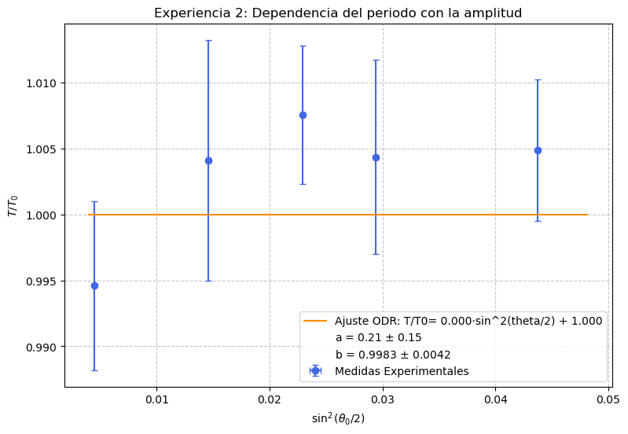

```python
plt.figure(figsize=(9, 6))

plt.errorbar(x_exp2, y_exp2, xerr=ux_exp2, yerr=uy_exp2,
             fmt='o', color='royalblue', label='Medidas Experimentales', capsize=3)

x_fit = np.linspace(min(x_exp2)*0.9, max(x_exp2)*1.1, 100)
y_fit = Lineal(out.beta, x_fit)
plt.plot(x_fit, y_fit, color='darkorange', label=rf'Ajuste ODR: T/T0= {out.beta[0]:.3f}·sin^2(theta/2) + {out.beta[1]:.3f}')
plt.plot ([], [], ' ', label = r"a = 0.21 $\pm$ 0.15")
plt.plot ([], [], ' ',label = r"b = 0.9983 $\pm$ 0.0042")
plt.xlabel(r'$\sin^2(\theta_0 / 2)$') # [cite: 106]
plt.ylabel(r'$T / T_0$') #
plt.title('Experiencia 2: Dependencia del periodo con la amplitud')
plt.grid(True, linestyle='--', alpha=0.7)
plt.legend()
plt.show()
```